# ML practice 5: regularization

### Данные

Вспомним данные про цены на жилье в Бостоне

```r
library(MASS)
#?Boston
```

- `crim` per capita crime rate by town
- `zn` proportion of residential land zoned for lots over 25,000 sq.ft
- `indus` proportion of non-retail business acres per town
- `chas` Charles River dummy variable (= 1 if tract bounds river; 0 otherwise).
- `nox` nitrogen oxides concentration (parts per 10 million).
- `rm` average number of rooms per dwelling.
- `age` proportion of owner-occupied units built prior to 1940.
- `dis` weighted mean of distances to five Boston employment centres.
- `rad` index of accessibility to radial highways.
- `tax` full-value property-tax rate per $10,000.
- `ptratio` pupil-teacher ratio by town.
- `black` 1000(Bk - 0.63)^2 where Bk is the proportion of blacks by town.
- `lstat` lower status of the population (percent).
- `medv` median value of owner-occupied homes in $1000s.

```r
data(Boston)
pander::pandoc.table(head(Boston), split.tables=Inf)
```

| crim | zn | indus | chas | nox | rm | age | dis | rad | tax | ptratio | black | lstat | medv |
| --- | --- | --- | --- | --- | --- | --- | --- | --- | --- | --- | --- | --- | --- |
| 0.00632 | 18 | 2.31 | 0 | 0.538 | 6.575 | 65.2 | 4.09 | 1 | 296 | 15.3 | 396.9 | 4.98 | 24 |
| 0.02731 | 0 | 7.07 | 0 | 0.469 | 6.421 | 78.9 | 4.967 | 2 | 242 | 17.8 | 396.9 | 9.14 | 21.6 |
| 0.02729 | 0 | 7.07 | 0 | 0.469 | 7.185 | 61.1 | 4.967 | 2 | 242 | 17.8 | 392.8 | 4.03 | 34.7 |
| 0.03237 | 0 | 2.18 | 0 | 0.458 | 6.998 | 45.8 | 6.062 | 3 | 222 | 18.7 | 394.6 | 2.94 | 33.4 |
| 0.06905 | 0 | 2.18 | 0 | 0.458 | 7.147 | 54.2 | 6.062 | 3 | 222 | 18.7 | 396.9 | 5.33 | 36.2 |
| 0.02985 | 0 | 2.18 | 0 | 0.458 | 6.43 | 58.7 | 6.062 | 3 | 222 | 18.7 | 394.1 | 5.21 | 28.7 |

```r
library(ggplot2)
library(caret)
```

# Обучающая и тестовая выборки

Отделим 20% от датасета. Как обычно, эта часть не будет использоваться для обучения модели, но на ней мы будем проверять (тестировать), насколько хороша наша модель.

```r
set.seed(6)
Boston.test.ind = sample(seq_len(nrow(Boston)), size = nrow(Boston)*0.2)
Boston.test = Boston[Boston.test.ind,]
Boston.train = Boston[-Boston.test.ind,]
```

### Линейная регрессия (повторение)

Построение модели

```r
lm.fit<-lm(medv~., data = Boston.train)
summary(lm.fit)
```

```
##
## Call:
## lm(formula = medv ~ ., data = Boston.train)
##
## Residuals:
##     Min      1Q  Median      3Q     Max
## -15.896  -2.778  -0.589   1.528  24.354
##
## Coefficients:
##               Estimate Std. Error t value Pr(>|t|)
## (Intercept)  39.333957   5.829973   6.747 5.46e-11 ***
## crim         -0.068299   0.056748  -1.204 0.229491
## zn            0.054013   0.015223   3.548 0.000435 ***
## indus         0.010441   0.068629   0.152 0.879156
## chas          2.715445   1.016126   2.672 0.007847 **
## nox         -18.176751   4.353078  -4.176 3.67e-05 ***
## rm            3.531637   0.469788   7.518 3.85e-13 ***
## age           0.010707   0.015102   0.709 0.478767
## dis          -1.612945   0.226542  -7.120 5.21e-12 ***
## rad           0.381849   0.079075   4.829 1.97e-06 ***
## tax          -0.015342   0.004320  -3.552 0.000429 ***
## ptratio      -0.980043   0.144038  -6.804 3.83e-11 ***
## black         0.011249   0.003099   3.630 0.000321 ***
## lstat        -0.589025   0.058806 -10.016  < 2e-16 ***
## ---
## Signif. codes:  0 '***' 0.001 '**' 0.01 '*' 0.05 '.' 0.1 ' ' 1
##
## Residual standard error: 4.841 on 391 degrees of freedom
## Multiple R-squared:  0.7418, Adjusted R-squared:  0.7332
## F-statistic: 86.42 on 13 and 391 DF,  p-value: < 2.2e-16
```

Соответствие предсказанных и реальных значений:

```r
lm.predictions <- predict(lm.fit, Boston.test)
summary(lm.fit)
```

```
##
## Call:
## lm(formula = medv ~ ., data = Boston.train)
##
## Residuals:
##     Min      1Q  Median      3Q     Max
## -15.896  -2.778  -0.589   1.528  24.354
##
## Coefficients:
##               Estimate Std. Error t value Pr(>|t|)
## (Intercept)  39.333957   5.829973   6.747 5.46e-11 ***
## crim         -0.068299   0.056748  -1.204 0.229491
## zn            0.054013   0.015223   3.548 0.000435 ***
## indus         0.010441   0.068629   0.152 0.879156
## chas          2.715445   1.016126   2.672 0.007847 **
## nox         -18.176751   4.353078  -4.176 3.67e-05 ***
## rm            3.531637   0.469788   7.518 3.85e-13 ***
## age           0.010707   0.015102   0.709 0.478767
## dis          -1.612945   0.226542  -7.120 5.21e-12 ***
## rad           0.381849   0.079075   4.829 1.97e-06 ***
## tax          -0.015342   0.004320  -3.552 0.000429 ***
## ptratio      -0.980043   0.144038  -6.804 3.83e-11 ***
## black         0.011249   0.003099   3.630 0.000321 ***
## lstat        -0.589025   0.058806 -10.016  < 2e-16 ***
## ---
## Signif. codes:  0 '***' 0.001 '**' 0.01 '*' 0.05 '.' 0.1 ' ' 1
##
## Residual standard error: 4.841 on 391 degrees of freedom
## Multiple R-squared:  0.7418, Adjusted R-squared:  0.7332
## F-statistic: 86.42 on 13 and 391 DF,  p-value: < 2.2e-16
```

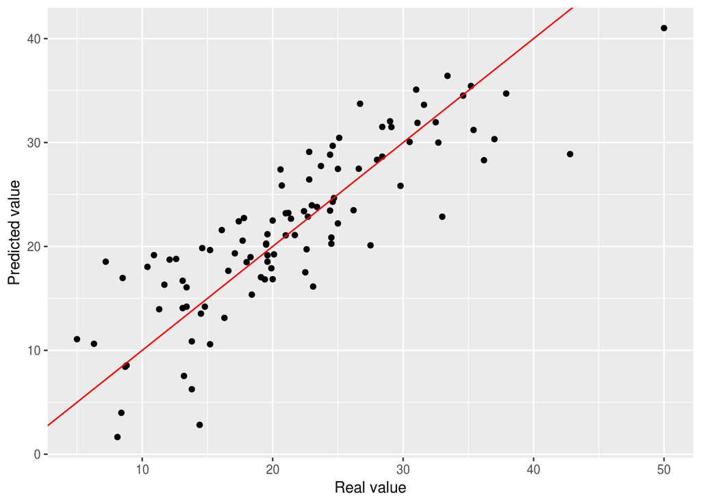

```r
ggplot()+geom_point((aes(x=Boston.test$medv, y=lm.predictions))) +
  geom_abline(color="red") +
  xlab("Real value") +
  ylab("Predicted value")
```

Ошибка предсказания

```r
lm.test.RSS = sum((lm.predictions-Boston.test$medv)^2)
lm.test.RSS
```

```
## [1] 2087.718
```

Итак, наша ошибка для обычной регрессии равна 2087.717786. Сможем ли мы сделать модель лучше? Может, нам нужны не все переменные?

### Регуляризация

Регуляризация – это способ строить модели так, чтобы коэффициенты были как можно меньше. В предельных случаях это приводит к тому, что некоторые коэффициенты становятся равными 0, т.е. исключаются из модели.

Чем же нам поможет регуляризация?

Одна из основных целей регуляризации, это выбор “оптимального” соотношения сложности модели и ее качества.

- А чем нам помогут не предельные случаи, т.е. просто уменьшение коэффициентов? Варианты?

Библиотека **glmnet** помогает нам выбрать такое оптимальное соотношение.

Если быть формально точным, то решает задачу
$$\min_{\beta_0,\beta} \frac{1}{N} \sum_{i=1}^{N} w_i l(y_i,\beta_0+\beta^T x_i) + \lambda\left[(1-\alpha)||\beta||_2^2 + \alpha ||\beta||_1\right].$$

В переводе на человеческий, формула выше содержит две части: левая – в нашем случае будет представлять сумму квадратов ошибок и правую – собственно регуляризация.

$||\beta||_1$ – это сумма модулей коэффициентов, и регрессия с такой регуляризацией называется **лассо (LASSO) регрессия** ($L_1$-регуляризация).

$||\beta||_2^2$ – это сумма квадратов коэффициентов, и регрессия с такой регуляризацией называется **гребневая (ridge) регрессия** ($L_2$-регуляризация).

Модель же смешивающая в какой-либо пропорции это два штрафа называется **эластичная сеть**

Давайте посмотрим, какой смысл в этих моделях, сравнив их с простой линейной регрессией.

### ЛАССО регрессия

Мы будем использовать пакет **glmnet**, однако он работает не с привычными нам формулами, а с матрицами. По этому нам надо еще немного подготовить наши данные. **model.matrix** используется и в обычной линейной регрессии, просто скрыто от нас. Она заодно превращает факторы в наборы индикаторных переменных.

```r
X.train <- model.matrix(medv~.-1, data=Boston.train)
X.test <- model.matrix(medv~.-1, data=Boston.test)
```

Попробуем прямо применить модель к нашим данным:

```r
library(glmnet)
glmnet.fit<-glmnet(X.train, Boston.train$medv)

glmnet.predictions <- predict(glmnet.fit, X.test)
```

Если мы посмотрим на свойства **glmnet.predictions**, то увидим, что вместо одного вектора мы получили … (а сколько же мы их получили?)

```r
str(glmnet.predictions)
```

```
##  num [1:101, 1:76] 22.8 22.8 22.8 22.8 22.8 ...
##  - attr(*, "dimnames")=List of 2
##   ..$ : chr [1:101] "307" "474" "134" "192" ...
##   ..$ : chr [1:76] "s0" "s1" "s2" "s3" ...
```

Помните, в формуле фигурировала величина $\lambda$, на которую домножается штраф. Так вот, по умолчанию **glmnet** строит не одну модель, а сразу много, для разных $\lambda$

Посмотрим на них:

```r
glmnet.fit$lambda
```

```
##  [1] 6.788898970 6.185791896 5.636263193 5.135553105 4.679324722
##  [6] 4.263626410 3.884857591 3.539737550 3.225277022 2.938752300
## [11] 2.677681645 2.439803788 2.223058344 2.025567968 1.845622092
## [16] 1.681662112 1.532267885 1.396145429 1.272115717 1.159104463
## [21] 1.056132817 0.962308888 0.876820019 0.798925745 0.727951384
## [26] 0.663282189 0.604358028 0.550668526 0.501748652 0.457174685
## [31] 0.416560546 0.379554455 0.345835883 0.315112777 0.287119026
## [36] 0.261612163 0.238371259 0.217195014 0.197900007 0.180319116
## [41] 0.164300063 0.149704098 0.136404799 0.124286972 0.113245660
## [46] 0.103185228 0.094018537 0.085666189 0.078055841 0.071121575
## [51] 0.064803330 0.059046381 0.053800863 0.049021343 0.044666422
## [56] 0.040698380 0.037082848 0.033788510 0.030786832 0.028051815
## [61] 0.025559769 0.023289109 0.021220169 0.019335028 0.017617357
## [66] 0.016052280 0.014626239 0.013326885 0.012142961 0.011064214
## [71] 0.010081300 0.009185705 0.008369672 0.007626133 0.006948649
## [76] 0.006331350
```

А в чем же смысл? Как мы помним, разные значения $\lambda$ будут по-разному выстраивать соотношение между штрафом и ошибкой. При $\lambda$ близкой к 0 мы получим обычную линейную регрессию. А что произойдет при большом значении $\lambda$? Какие ваши идеи?

Давайте посмотрим на прогноз при большом значении $\lambda$

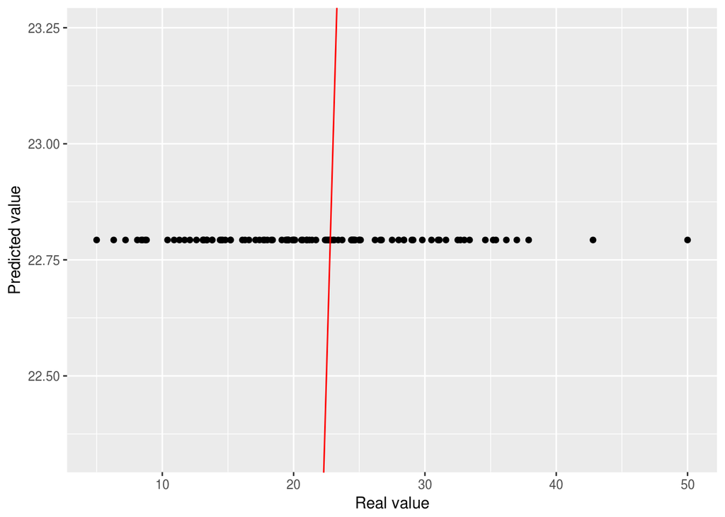

```r
ggplot()+geom_point((aes(x=Boston.test$medv, y=glmnet.predictions[,1]))) +
  geom_abline(color="red") +
  xlab("Real value") +
  ylab("Predicted value")
```

Что произошло? Как это объяснить?

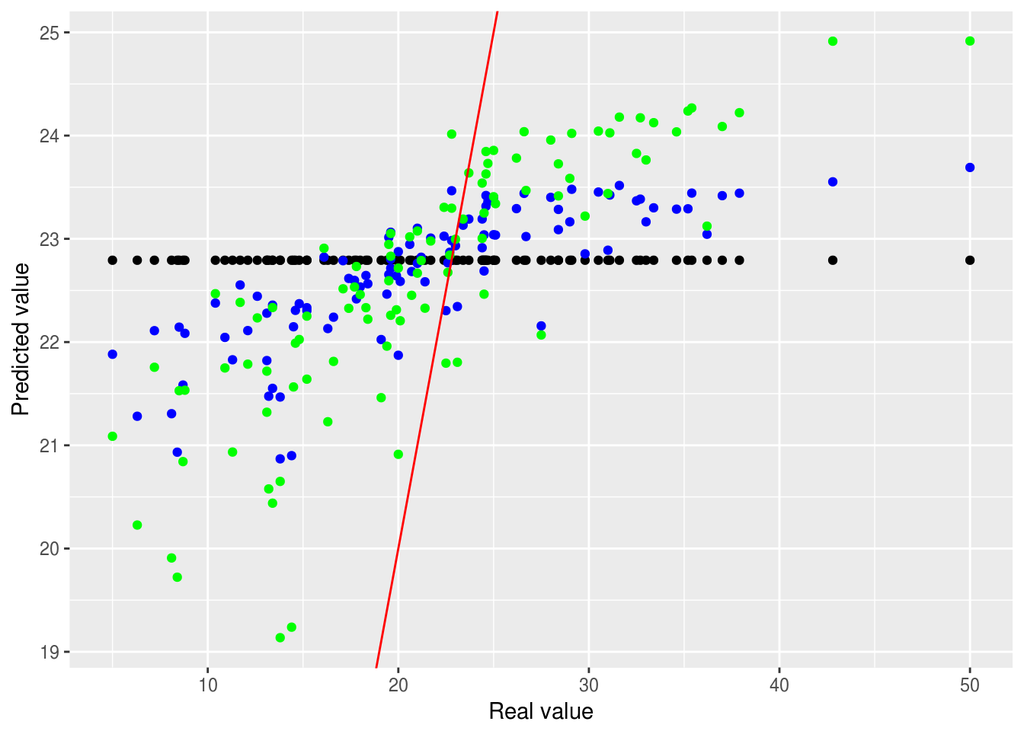

```r
ggplot()+geom_point(aes(x=Boston.test$medv, y=glmnet.predictions[,1])) +
  geom_point(aes(x=Boston.test$medv, y=glmnet.predictions[,2]), color = "blue") +
  geom_point(aes(x=Boston.test$medv, y=glmnet.predictions[,3]), color = "green") +
  geom_abline(color="red") +
  xlab("Real value") +
  ylab("Predicted value")
```

Попробуйте нарисовать графики для разных $\lambda$ и сделать выводы. Что меняется при изменении $\lambda$?

Посчитаем теперь ошибку для каждой из моделей:

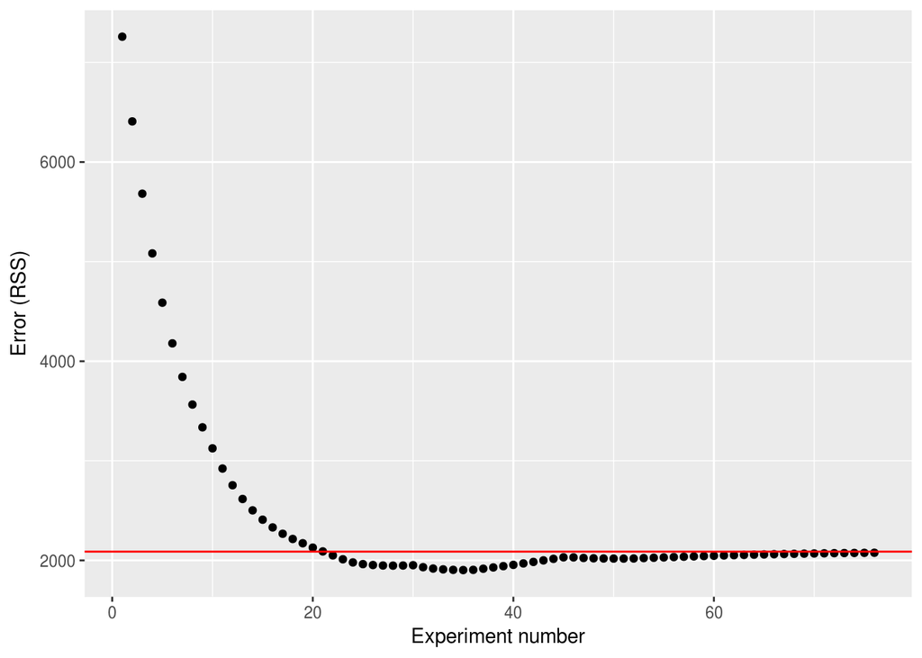

```r
glmnet.test.RSS <- colSums((glmnet.predictions-Boston.test$medv)^2)
ggplot()+
  geom_point(aes(x=1:length(glmnet.test.RSS), y=glmnet.test.RSS)) +
  geom_hline(aes(yintercept=lm.test.RSS), color="red") +
  xlab("Experiment number") +
  ylab("Error (RSS)")
```

Мы видим что при некоторых значениях $\lambda$, результаты на тестовой выборке лучше. Но прежде чем мы поучимся подбирать $\lambda$, давайте посмотрим, как связаны коэффициенты в регрессии и $\lambda$.

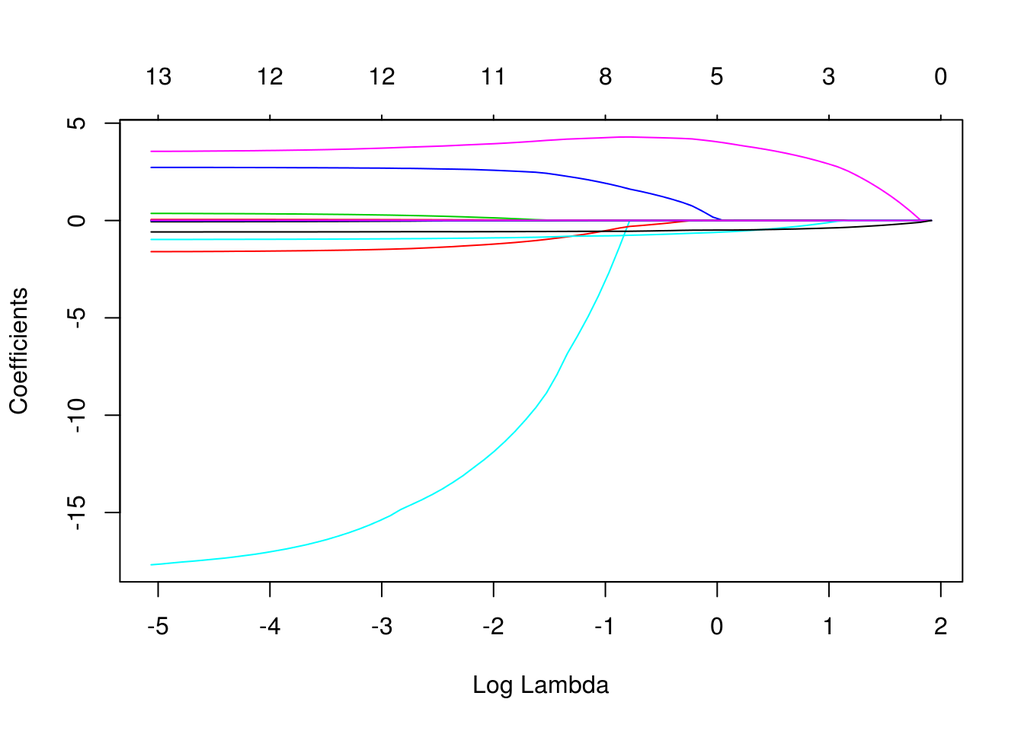

```r
plot(glmnet.fit,xvar="lambda")
```

Этот график показывают нам, какие из переменных важны, а какие не очень. Но можно посмотреть и по другому, **print()** выведет нам количество ненулевых коэффициентов и объясненную долю дисперсии для каждого значения $\lambda$.

```r
print(glmnet.fit)
```

```
##
## Call:  glmnet(x = X.train, y = Boston.train$medv)
##
##       Df   %Dev   Lambda
##  [1,]  0 0.0000 6.789000
##  [2,]  2 0.0893 6.186000
##  [3,]  2 0.1812 5.636000
##  [4,]  2 0.2574 5.136000
##  [5,]  2 0.3207 4.679000
##  [6,]  2 0.3733 4.264000
##  [7,]  2 0.4169 3.885000
##  [8,]  2 0.4532 3.540000
##  [9,]  2 0.4832 3.225000
## [10,]  3 0.5111 2.939000
## [11,]  3 0.5379 2.678000
```

[output cut: 65 more lines]

Или то же самое на графике:

```r
str(glmnet.fit)
```

```
## List of 12
##  $ a0       : Named num [1:76] 22.8 23.9 21.5 19.4 17.4 ...
##   ..- attr(*, "names")= chr [1:76] "s0" "s1" "s2" "s3" ...
##  $ beta     :Formal class 'dgCMatrix' [package "Matrix"] with 6 slots
##   .. ..@ i       : int [1:623] 5 12 5 12 5 12 5 12 5 12 ...
##   .. ..@ p       : int [1:77] 0 0 2 4 6 8 10 12 14 16 ...
##   .. ..@ Dim     : int [1:2] 13 76
##   .. ..@ Dimnames:List of 2
##   .. .. ..$ : chr [1:13] "crim" "zn" "indus" "chas" ...
##   .. .. ..$ : chr [1:76] "s0" "s1" "s2" "s3" ...
##   .. ..@ x       : num [1:623] 0.000147 -0.085912 0.471433 -0.134396 0.900526 ...
##   .. ..@ factors : list()
##  $ df       : int [1:76] 0 2 2 2 2 2 2 2 2 3 ...
##  $ dim      : int [1:2] 13 76
##  $ lambda   : num [1:76] 6.79 6.19 5.64 5.14 4.68 ...
##  $ dev.ratio: num [1:76] 0 0.0893 0.1812 0.2574 0.3207 ...
##  $ nulldev  : num 35491
##  $ npasses  : int 735
##  $ jerr     : int 0
##  $ offset   : logi FALSE
##  $ call     : language glmnet(x = X.train, y = Boston.train$medv)
##  $ nobs     : int 405
##  - attr(*, "class")= chr [1:2] "elnet" "glmnet"
```

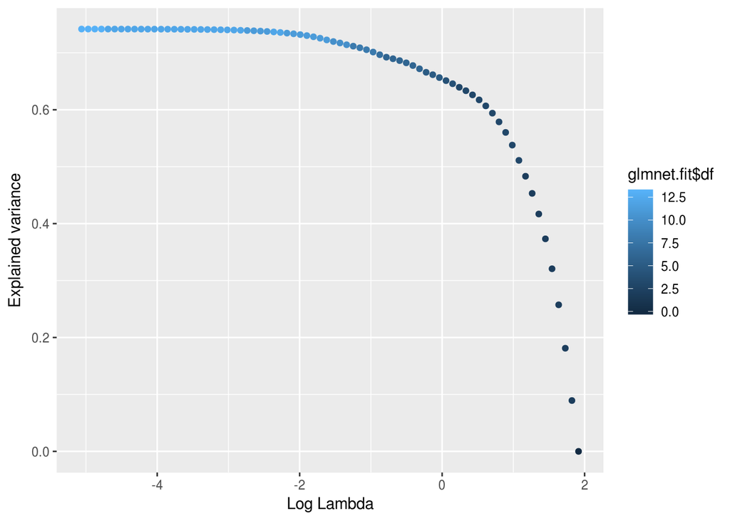

```r
ggplot()+
  geom_point(aes(x=log(glmnet.fit$lambda), y=glmnet.fit$dev.ratio, color = glmnet.fit$df)) +
  xlab("Log Lambda") +
  ylab("Explained variance")
```

Теперь посмотрим на способ получить “оптимальное” значение $\lambda$. Если бы мы смотрели на тестовое множество, то можно было бы выбрать $\lambda$ по нему. Но мы считаем, что оно нам недоступно и представляет собой “данные из реального мира”.

Если у нас нет тестового множества, надо его придумать! А чтобы не сломать все неудачным выбором тестового множества, мы вспомним кросс-валидацию. *glmnet* сам умеет выбирать $\lambda$ на основе кросвалидации.

```r
cv.glmnet.fit<-cv.glmnet(X.train, Boston.train$medv)
cv.glmnet.fit
```

```
## $lambda
##  [1] 6.788898970 6.185791896 5.636263193 5.135553105 4.679324722
##  [6] 4.263626410 3.884857591 3.539737550 3.225277022 2.938752300
## [11] 2.677681645 2.439803788 2.223058344 2.025567968 1.845622092
## [16] 1.681662112 1.532267885 1.396145429 1.272115717 1.159104463
## [21] 1.056132817 0.962308888 0.876820019 0.798925745 0.727951384
## [26] 0.663282189 0.604358028 0.550668526 0.501748652 0.457174685
## [31] 0.416560546 0.379554455 0.345835883 0.315112777 0.287119026
## [36] 0.261612163 0.238371259 0.217195014 0.197900007 0.180319116
## [41] 0.164300063 0.149704098 0.136404799 0.124286972 0.113245660
## [46] 0.103185228 0.094018537 0.085666189 0.078055841 0.071121575
## [51] 0.064803330 0.059046381 0.053800863 0.049021343 0.044666422
## [56] 0.040698380 0.037082848 0.033788510 0.030786832 0.028051815
## [61] 0.025559769 0.023289109 0.021220169 0.019335028 0.017617357
## [66] 0.016052280 0.014626239 0.013326885 0.012142961 0.011064214
```

[output cut: 160 more lines]

```r
best.lambda <- cv.glmnet.fit$lambda.min
best.lambda
```

```
## [1] 0.01761736
```

Мы получили какое-то $\lambda$. Давайте его подставим и посмотрим, чем это закончится.

```r
glmnet.fit.best<-glmnet(X.train, Boston.train$medv, lambda = best.lambda)
coef(glmnet.fit.best)
```

```
## 14 x 1 sparse Matrix of class "dgCMatrix"
##                        s0
## (Intercept)  37.937851170
## crim         -0.057770353
## zn            0.050671656
## indus         .
## chas          2.717758452
## nox         -17.091942354
## rm            3.590790199
## age           0.007719397
## dis          -1.573462267
## rad           0.345713108
## tax          -0.013769431
## ptratio      -0.964746959
## black         0.011147313
## lstat        -0.584667267
```

```r
glmnet.predictions.best <- predict(glmnet.fit.best, X.test)
glmnet.best.test.RSS <- sum((glmnet.predictions.best-Boston.test$medv)^2)
```

Мы можем сравнить две оценки. Просто регрессия дала нам 2087.717786 а LASSO 2060.6070999.

### Ridge регрессия

Мы посмотрели на LASSO, а чем же отличается ridge модель.

В этом примере, мы сразу построим оптимальные по кросвалидации значения, для ridge и для elastic net, вам же предлагается повторить, все что было выше и понять как эти модели работают.

```r
ridge<-cv.glmnet(X.train, Boston.train$medv, alpha = 0)
elastic<-cv.glmnet(X.train, Boston.train$medv, alpha = 0.5)

ridge.test.RSS<-sum((predict(ridge,X.test)-Boston.test$medv)^2)
elastic.test.RSS<-sum((predict(elastic,X.test)-Boston.test$medv)^2)
```

По ошибкам мы получили:

| Метод | RSS |
| --- | --- |
| LM | 2087.717786 |
| LASSO | 2060.6070999 |
| Ridge | 1733.303655 |
| Elastic 0.5 | 1949.9101092 |

Какую модель выбрать?

**Ваша очередь:**

- Постройте регрессионые модели для данных о продаже (`Sales`) детских кресел, но для случая логистической регрессии `glmnet.fit<-glmnet(X.train, ..., family = "binomial")`

```r
library(ISLR)
data(Carseats)
```

```r
?Carseats
carseats <- ISLR::Carseats
сarseats <- carseats %>%
  mutate(High = ifelse(Sales <= 8, "No", "Yes")) %>%
  dplyr::select(-Sales)
```

```r
pander::pandoc.table(head(Carseats), split.tables=Inf)
```

| Sales | CompPrice | Income | Advertising | Population | Price | ShelveLoc | Age | Education | Urban | US |
| --- | --- | --- | --- | --- | --- | --- | --- | --- | --- | --- |
| 9.5 | 138 | 73 | 11 | 276 | 120 | Bad | 42 | 17 | Yes | Yes |
| 11.22 | 111 | 48 | 16 | 260 | 83 | Good | 65 | 10 | Yes | Yes |
| 10.06 | 113 | 35 | 10 | 269 | 80 | Medium | 59 | 12 | Yes | Yes |
| 7.4 | 117 | 100 | 4 | 466 | 97 | Medium | 55 | 14 | Yes | Yes |
| 4.15 | 141 | 64 | 3 | 340 | 128 | Bad | 38 | 13 | Yes | No |
| 10.81 | 124 | 113 | 13 | 501 | 72 | Bad | 78 | 16 | No | Yes |

- Какая модель дает лучшее предсказание на тестовой выборке? Какие предикторы в нее входят?